# TalkingData AdTracking Fraud Detection Challenge

Análise de dados + criação de um modelo de machine learning com redes neurais e random forest, para detecção de cliques fraudulentos.

Pablo Aguiar Raposo

30/04/2022

# 1 Introdução: Motivação, objetivo, carregamento dos dados e análise exploratória inicial

OBS: Este projeto é baseado em um competição do Kaggle. Os datasets estão presentes em https://www.kaggle.com/competitions/talkingdata-adtracking-fraud-detection/data. Todo o trabalho foi realizado em linguagem R e o relatório final foi obtido através do Rmarkdown.

## 1.1 Objetivo

Analisar os dados disponibilizados pela empresa Talkingdata e criar um modelo de machine learning que determinará se um clique é fraudulento ou não, usando redes neurais e random forest.

## 1.2 Motivação

O risco de fraude está em toda parte, mas para as empresas que anunciam online, a fraude de cliques pode acontecer em um volume avassalador, resultando em dados de cliques enganosos e dinheiro desperdiçado. Os canais de anúncios podem aumentar os custos simplesmente quando pessoas ou bots clicam nos anúncios em grande escala, o que na prática não gera o resultado esperado. Com mais de 1 bilhão de dispositivos móveis em uso todos os meses, a China é o maior mercado móvel do mundo e, portanto, sofre com grandes volumes de tráfego fraudulento. Neste projeto, utilizaremos um dataset disponibilizado pela empresa Talkingdata, para construir uma análise de dados e um modelo de machine learning que classifica um clique como sendo fraudulento ou não.

## 1.4 Dicionário de dados:

### 1.4.1 ip: endereço de IP do clique;

### 1.4.2 app: ID do aplicativo usado no marketing;

### 1.4.3 device: ID do tipo de aparelho utilizado;

### 1.4.4 os: Versão do sistema operacional do aparelho;

### 1.4.5 channel: ID do canal do anuciante

### 1.4.6 click_time: Horário de clique (UTC)

### 1.4.7 attributed_time: Se o usuário fez o download do app, o horário em que foi feito esse download

### 1.4.8 is_attributed: Variável a ser prevista, indica se o app foi baixado(1) ou não(0).

## 1.5 Carregando pacotes utilizados no projeto

```r
library(ggplot2)
library(neuralnet)
library(caret)
library(dplyr)
library(randomForest)
library(data.table)
library(knitr)
```

## 1.6 Carregando dados

```r
data <- fread("train_sample.csv", header = T)
```

## 1.7 seed

```r
set.seed(15)
```

## 1.8 Visualizando os dados

```r
str(data)
```

```
## Classes 'data.table' and 'data.frame':   100000 obs. of  8 variables:
##  $ ip             : int  87540 105560 101424 94584 68413 93663 17059 121505 192967 143636 ...
##  $ app            : int  12 25 12 13 12 3 1 9 2 3 ...
##  $ device         : int  1 1 1 1 1 1 1 1 2 1 ...
##  $ os             : int  13 17 19 13 1 17 17 25 22 19 ...
##  $ channel        : int  497 259 212 477 178 115 135 442 364 135 ...
##  $ click_time     : POSIXct, format: "2017-11-07 09:30:38" "2017-11-07 13:40:27" ...
##  $ attributed_time: POSIXct, format: NA NA ...
##  $ is_attributed  : int  0 0 0 0 0 0 0 0 0 0 ...
##  - attr(*, ".internal.selfref")=<externalptr>
```

```r
kable(head(data))
```

| ip | app | device | os | channel | click_time | attributed_time | is_attributed |
| --- | --- | --- | --- | --- | --- | --- | --- |
| 87540 | 12 | 1 | 13 | 497 | 2017-11-07 09:30:38 | NA | 0 |
| 105560 | 25 | 1 | 17 | 259 | 2017-11-07 13:40:27 | NA | 0 |
| 101424 | 12 | 1 | 19 | 212 | 2017-11-07 18:05:24 | NA | 0 |
| 94584 | 13 | 1 | 13 | 477 | 2017-11-07 04:58:08 | NA | 0 |
| 68413 | 12 | 1 | 1 | 178 | 2017-11-09 09:00:09 | NA | 0 |
| 93663 | 3 | 1 | 17 | 115 | 2017-11-09 01:22:13 | NA | 0 |

A coluna ‘attributed_time’ possui grande quantidade de valores NA, pois ela só está presente quando o download do app é relaizado.

#### 1.8.0.1 Checando a existência de valores NA para outras variáveis

```r
sum(is.na(data[,-'attributed_time']))
```

```
## [1] 0
```

#### 1.8.0.2 Verificando se existe algum erro com as variáveis temporais, verificando se existe registro de algum download ocorrendo antes do click na propaganda

```r
x = data %>% filter(click_time - attributed_time > 0)
nrow(x)
```

```
## [1] 0
```

Podemos perceber que está tudo correto.

# 2 Data munging

## 2.1 Checando através de um plot a quantidade de valores únicos de cada uma das variáveis.

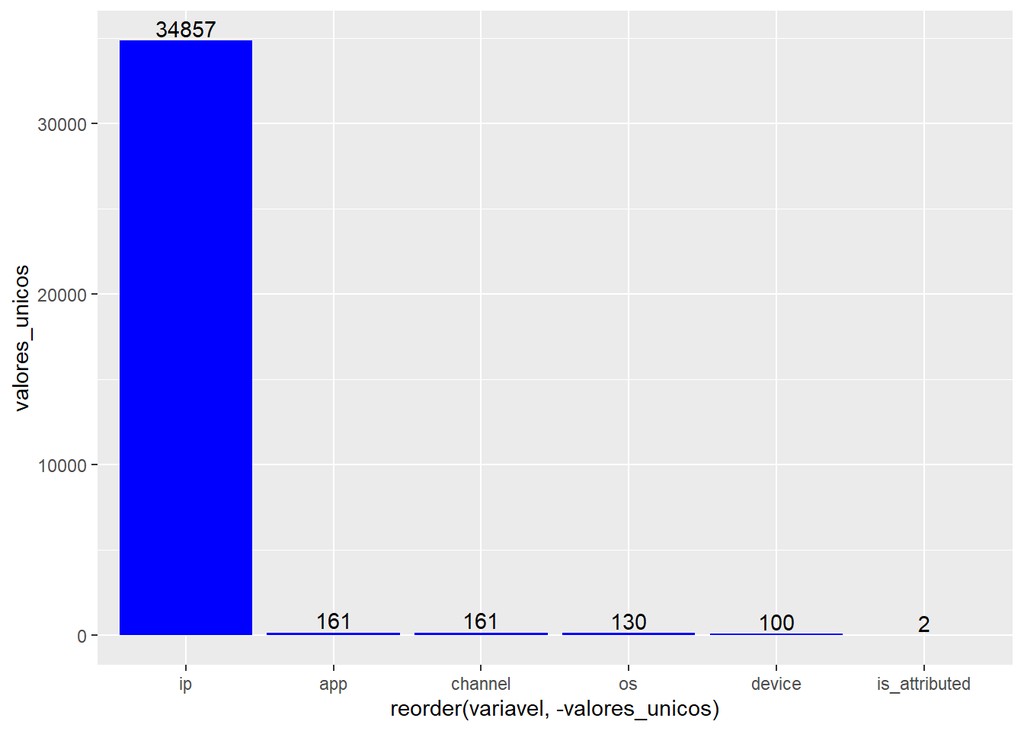

```r
unique_values <- data[,-c('click_time','attributed_time')]
unique_values <- as.data.frame(apply(unique_values, 2, function(x) length(unique(x))))
unique_values$names <- rownames(unique_values)
colnames(unique_values) <- c('valores_unicos','variavel')
unique_values <- unique_values %>% arrange(desc(valores_unicos))

ggplot(unique_values, aes( x=reorder(variavel,-valores_unicos),valores_unicos)) +
  geom_bar(position='dodge', stat='identity',fill = "blue") +
  geom_text(aes(label=valores_unicos), position=position_dodge(width=0.9), vjust=-0.25)
```

Podemos perceber uma enorme quantidade de IPs únicos. Importante notar que a variável que iremos prever possui apenas 2 valores únicos, que é o comportamento esperado.

## 2.2 Balanceamento de variável

Em problemas de classificação, é importante que a variável a ser prevista esteja balanceada, ou seja, a quantidade de valores 0 e de valores 1 em ‘is_attributed’ deve ser parecida.

##### 2.2.0.0.1 Vamos plotar essas quantidades

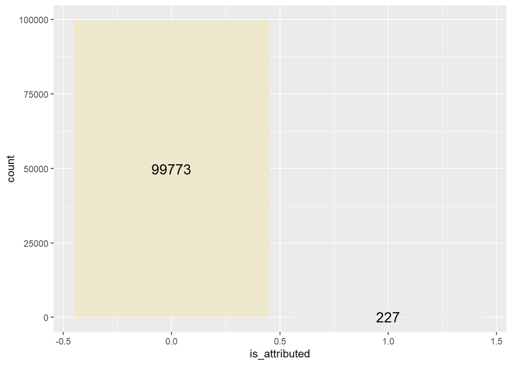

```r
ggplot(data, aes(is_attributed)) + geom_bar(fill = 'cornsilk2') +
  stat_count(geom = "text", colour = "black", size = 5,
             aes(label = ..count..),position=position_stack(vjust=0.5))
```

Percebemos uma enorme necessidade de balancear os dados.Podemos fazer isso reduzindo nossa amostra onde ‘is_attributed’ for 0 ou criando dados em que ‘is_attributed’ é 1. Como temos acesso a uma quantidade muito grande de dados, usaremos uma técnica de downsample

```r
yes <- which(data$is_attributed == 1)
no <- which(data$is_attributed == 0)
not_downloaded_sample <- sample(no, length(yes))
data = data[c(not_downloaded_sample,yes),]
```

### 2.2.1 Verificando

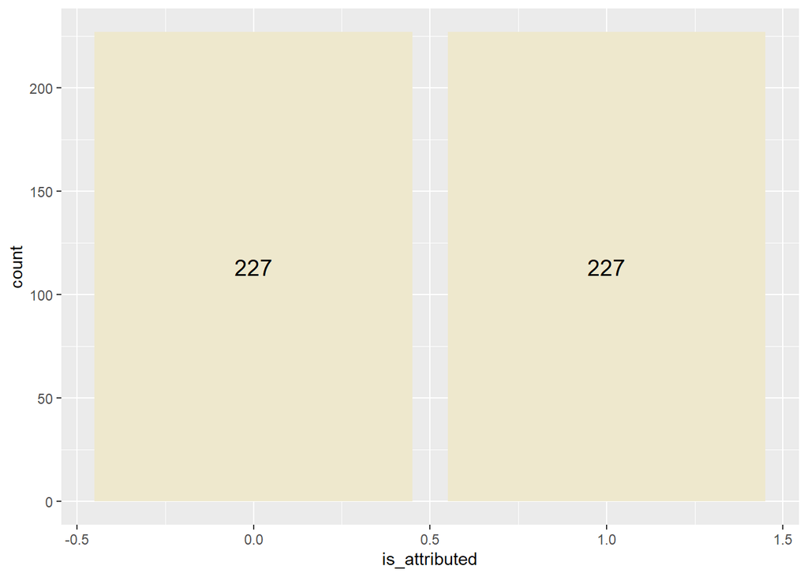

```r
ggplot(data, aes(is_attributed)) + geom_bar(fill = 'cornsilk2') +
  stat_count(geom = "text", colour = "black", size = 5,
             aes(label = ..count..),position=position_stack(vjust=0.5))
```

Agora sim a variável target está balanceada.

## 2.3 Criando coluna com dia da semana e horário do clique

```r
data$dayweek =  wday(data$click_time)
data$hour = hour(data$click_time)
```

```r
kable(head(data[,c('click_time','dayweek','hour')]))
```

| click_time | dayweek | hour |
| --- | --- | --- |
| 2017-11-09 01:27:11 | 5 | 1 |
| 2017-11-07 19:14:02 | 3 | 19 |
| 2017-11-08 06:39:30 | 4 | 6 |
| 2017-11-07 11:03:39 | 3 | 11 |
| 2017-11-07 11:48:26 | 3 | 11 |
| 2017-11-08 02:38:46 | 4 | 2 |

# 3 Análise - quem fez o download do app

## 3.1 Criando subset apenas com os dados dos que baixaram o app(data2)

```r
data2 = subset(data, data$is_attributed == 1)
```

## 3.2 Análise: média de tempo levado para download do app

```r
data2$delay = as.numeric(data2$attributed_time - data2$click_time)
```

```r
mean(data2$delay/60)
```

```
## [1] 74.99288
```

```r
sd(data2$delay/60)
```

```
## [1] 145.0899
```

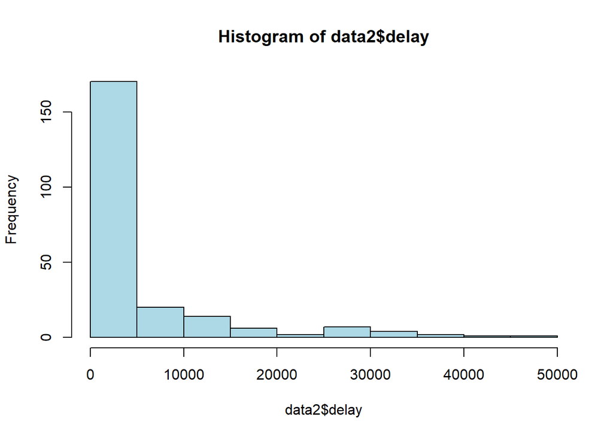

```r
hist(data2$delay, breaks = 10, col = 'lightblue')
```

### 3.2.1 Considerando pessoas que demoraram menos de 10min(600s)

```r
delay_under10 = subset(data2, select = delay, subset = delay<600 )
mean(delay_under10$delay/60)
```

```
## [1] 1.780224
```

```r
sd(delay_under10$delay/60)
```

```
## [1] 1.927303
```

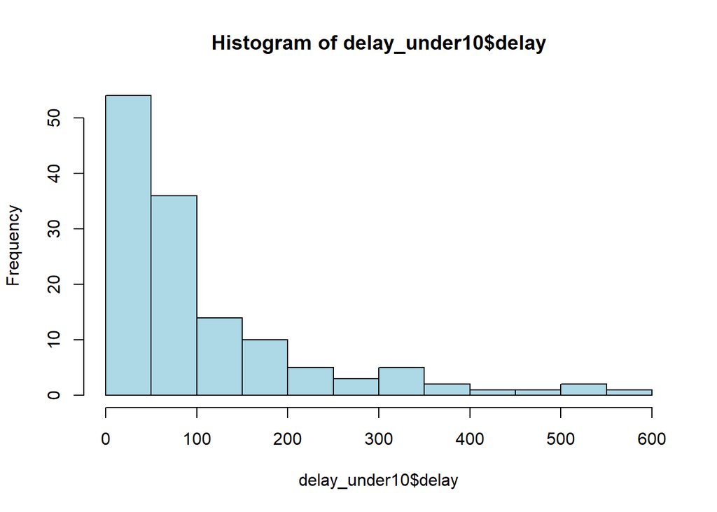

```r
hist(delay_under10$delay, breaks = 10, col = 'lightblue')
```

### 3.2.2 % de pessoas que baixaram o app

```r
a = nrow(data2)
b = nrow(data)
a/b*100
```

```
## [1] 50
```

### 3.2.3 % de pessoas que baixaram o app em menos de 2 minutos(120s)

```r
c = subset(data2, subset = data2$delay < 120)
d = nrow(c)
d/a*100
```

```
## [1] 42.73128
```

### 3.2.4 Concluímos que, das pessoas que baixaram o app, 42.7312775 o fizeram em menos de 2 minutos, apesar da média ser de 74.9928781 minutos.

## 3.3 Descobrindo quantos dias estão presentes no nosso dataset

```r
max(data$click_time) - min(data$click_time)
```

```
## Time difference of 2.943634 days
```

## 3.4 Criando um gráfico que mostra o horário do click em uma propaganda, comparando quem fez o download com quem não fez.

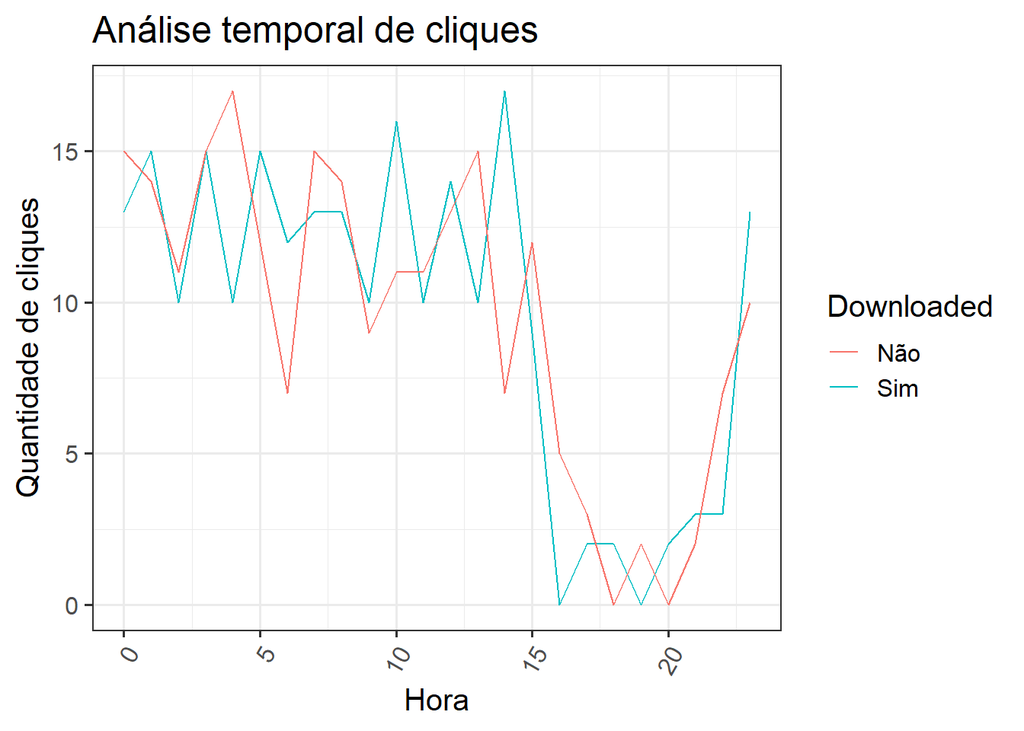

```r
data %>%
  group_by(hour) %>%
  summarise(downloadsRealized = sum(is_attributed),
            unrealizedDownloads = sum(!is_attributed)) %>%
  ggplot(x = factor(hour)) +
  geom_line(aes(x = hour, y = downloadsRealized, color = 'Sim')) +
  geom_line(aes(x = hour, y = unrealizedDownloads, color = 'Não')) +
  theme_bw(base_size = 15) +
  theme(axis.text.x = element_text(angle = 60, hjust = 1)) +
  xlab('Hora') +
  ylab('Quantidade de cliques') +
  labs(title = 'Análise temporal de cliques', colour = 'Downloaded')
```

## 3.5 Analizando os IPs que fizeram ou não o download.

#### 3.5.0.1 Ips que fizeram o download:

```r
ip_downloaded = data %>% select(c('ip', 'is_attributed')) %>% filter(is_attributed == 1) %>% distinct()
```

#### 3.5.0.2 Ips que não fizeram o dowload

```r
ip_not_donwloaded = data %>% select(c('ip', 'is_attributed')) %>% filter(is_attributed == 0) %>% distinct()
```

#### 3.5.0.3 IPs que pertencem aos dois grupos

```r
ip_both = ip_downloaded %>% inner_join(ip_not_donwloaded , by = 'ip')
count(ip_downloaded)
```

```
##      n
## 1: 223
```

```r
count(ip_not_donwloaded)
```

```
##      n
## 1: 219
```

```r
count(ip_both)
```

```
##    n
## 1: 4
```

É possível perceber que uma quantidade extremamente baixa de IPs foi responsável por cliques fraudulentos e cliques não fraudulentos. Assim, percebemos que o mesmo IP costuma ter o mesmo comportamento, seja fraudar o clique ou não.

```r
ip_only_downloaded = ip_downloaded %>% anti_join(ip_both)
ip_only_not_downloaded = ip_not_donwloaded %>% anti_join(ip_both)
total_IP = count(ip_downloaded) + count(ip_not_donwloaded) - count(ip_both)
count(ip_only_downloaded) / total_IP *100
```

```
##     n
## 1: 50
```

```r
count(ip_only_not_downloaded) / total_IP *100
```

```
##           n
## 1: 49.08676
```

O total de Ips que nunca resultaram em cliques fraudulentos é de 50 % . Já o total que sempre resultou em clique fraudulento é de 49.086758 %